# PA1

# Step Analysis

## Loading Data

```r
data = read.csv(unz('activity.zip','activity.csv'))
```

## Mean total number of steps per day

#### 1) Histogram of total number of steps taken per day:

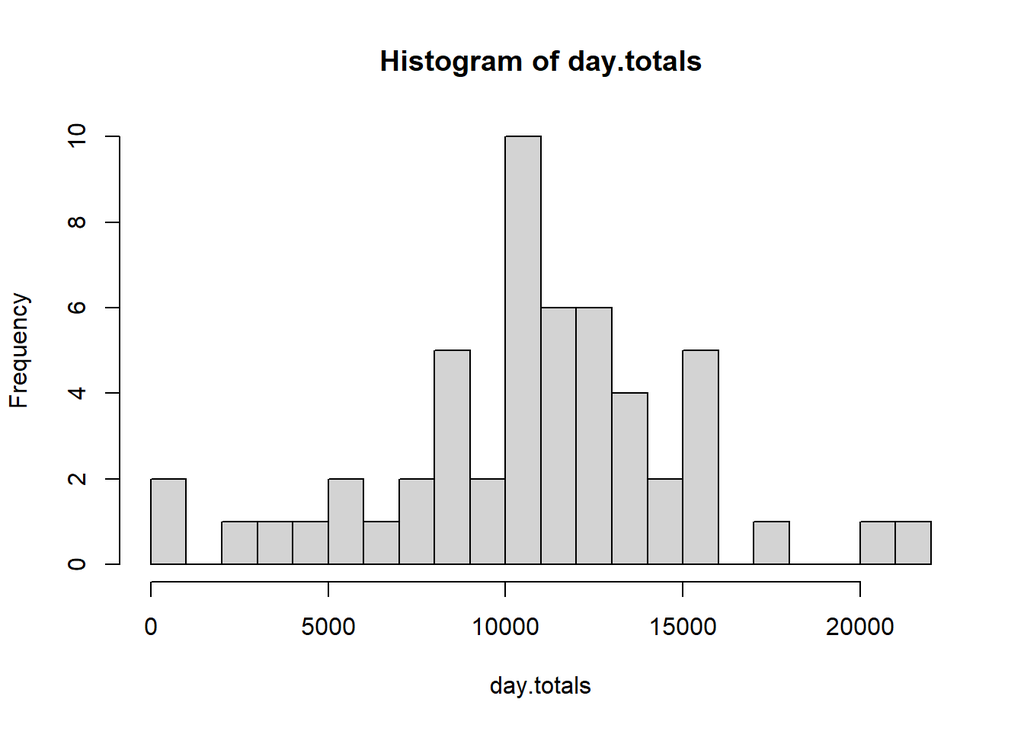

```r
day.totals = sapply(lapply(split(data,data$date),'[[',1),sum)
hist(day.totals,breaks=20)
```

As can be seen from the plot the total number of steps taken per day is approximately normally distributed.

#### 2) The mean number of steps taken per day:

```r
mean(day.totals,na.rm=T)
```

```
## [1] 10766.19
```

The median number of steps taken per day:

```r
median(day.totals,na.rm=T)
```

```
## [1] 10765
```

This is close to the mean and so could support the idea that day.totals is normally distributed.

## What is the average daily activity pattern?

#### 1) Time series plot:

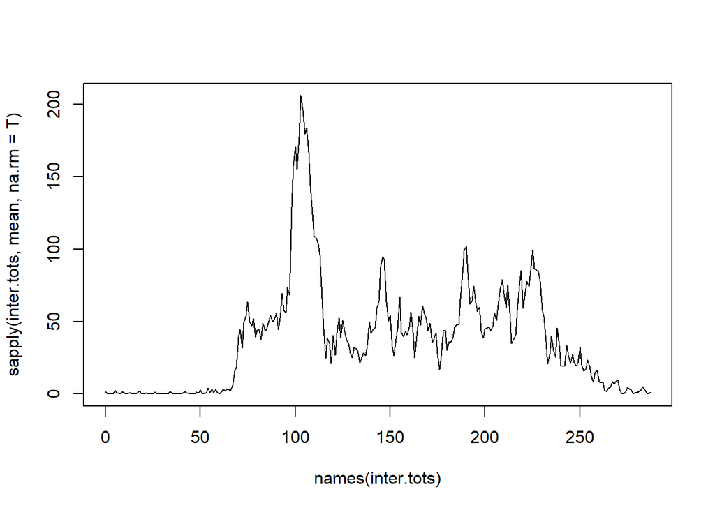

```r
inter.tots = lapply(split(data,data$interval),'[[',1) # list of step counts for each interval
names(inter.tots) = time(names(inter.tots)) - 1 # reformat interval names to be sequential
plot(names(inter.tots),sapply(inter.tots,mean,na.rm=T),type='l') # plot mean of each interval as time series
```

#### 2) Which 5-minute interval, on average across all the days in the dataset,

contains the maximum number of steps?

```r
which(sapply(inter.tots,mean,na.rm=T) == max(sapply(inter.tots,mean,na.rm=T)))
```

```
## 103
## 104
```

## Imputing Missing Values

#### 1) Total missing values?

```r
sum(is.na(data$steps))
```

```
## [1] 2304
```

#### 3)/4) Create a new dataset that is equal to the original dataset but with the missing data filled in. Make a histogram of the total number of steps taken each day and Calculate and report the mean and median total number of steps taken per day. Do these values differ from the estimates from the first part of the assignment? What is the impact of imputing missing data on the estimates of the total daily number of steps?

First, create data2, identical to data. Then, replace NA step values for the mean of the corresponding interval.

```r
inter.tots = lapply(split(data,data$interval),'[[',1) # list of step counts for each interval
inter.means = sapply(inter.tots,mean,na.rm=T)
data2 = data
data2$steps = sapply(seq_along(data$steps),function(x) {
  if (is.na(data[x,1])) {as.numeric(inter.means[as.character(data[x,3])])} else {as.numeric(data[x,1])}
  })
```

Now, we calculate the total steps for each day and plot a histogram:

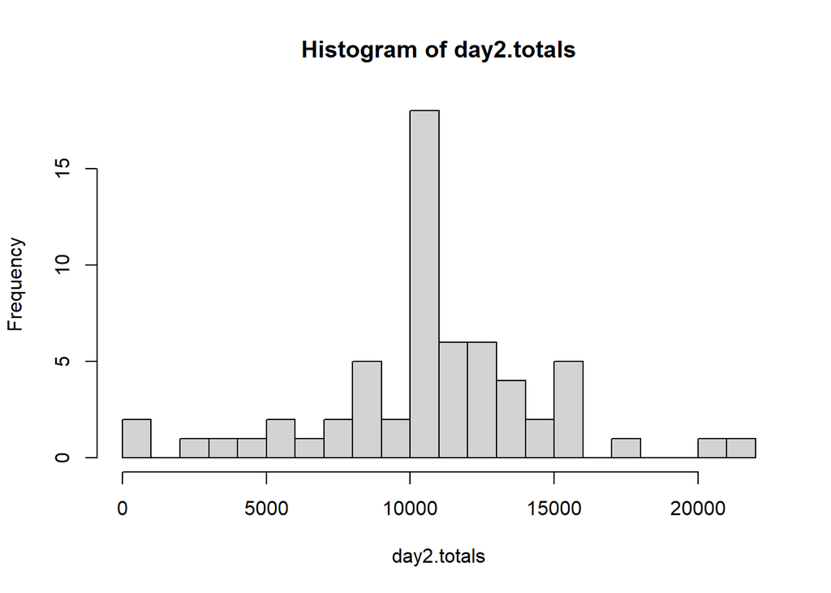

```r
day2.totals = sapply(lapply(split(data2,data2$date),'[[',1),sum)
hist(day2.totals,breaks=20)
```

We can see the distribution has been centered more strongly to the mean, confirmed by comparing the standard deviations of our original data and imputed data:

```r
sd(day.totals,na.rm = T)
```

```
## [1] 4269.18
```

```r
sd(day2.totals)
```

```
## [1] 3974.391
```

This is mostly due to a number of days that are completely missing, and so when each interval is imputed with the mean of that interval, the total steps for that day will be equal to the mean.

Looking at the mean and medians of the data sets:

```r
medians = data.frame(data=median(day.totals,na.rm = T),data2=median(day2.totals,na.rm=T))
means = data.frame(data=mean(day.totals,na.rm = T),data2=mean(day2.totals,na.rm=T))
means
```

```
##       data    data2
## 1 10766.19 10766.19
```

```r
medians
```

```
##    data    data2
## 1 10765 10766.19
```

#### Are there differences in activity patterns between weekdays and weekends?

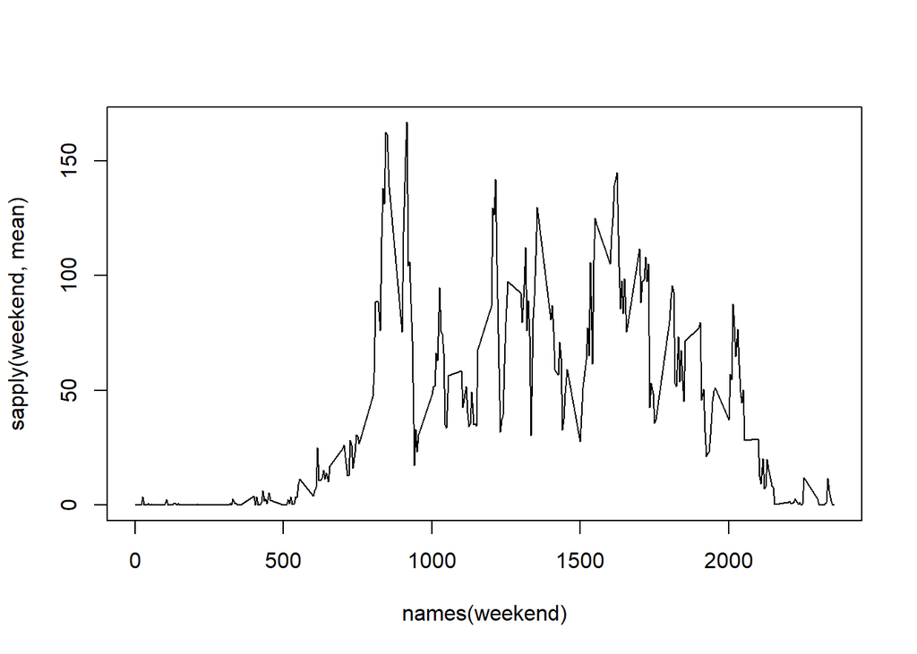

```r
days = weekdays(as.POSIXct(data2$date))
data2$weekend = 1*(days %in% c('Saturday','Sunday'))
weekend = lapply(split(data2[which(data2$weekend==1),],data2[which(data2$weekend==1),]$interval),'[[',1)
weekday = lapply(split(data2[which(data2$weekend==0),],data2[which(data2$weekend==0),]$interval),'[[',1)

plot(names(weekend),sapply(weekend,mean),type='l')
```

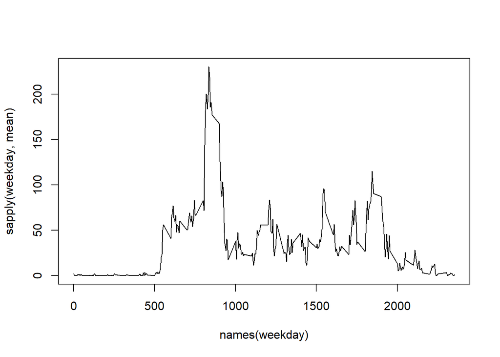

```r
plot(names(weekday),sapply(weekday,mean),type='l')
```